# Working with Alignments

```python
# sudo apt-get update -y
# sudo apt-get install -y ugene

# sudo apt install prank
```

With UGENE installation also several tools are installed:

- clustalw
- clustalo
- muscle
- mafft
- t-coffee

```python
import Bio.SeqIO as IO
```

### Info about input data and programms

**Input data**

- **Ogranism:** Saccharomyces cerevisiae
- **Gene:** SUP35
- **Protein:** Eukaryotic peptide chain release factor GTP-binding subunit

**Programs:**

```
- ClustalW v2.1
- Clustal Omega v1.2.4
- MUSCLE v3.8.1551
- MAFFT v7.453
- Kalign v2.04
- t-coffee v11.0.8
- prank v.170427
- EMBOSS:6.6.0.0
```

### Launch different alignment algorithms on the file SUP35_10seqs.fa

`SUP35_10seqs.fa` contains 10 sequences of the gene SUP35 from different S. cerevisiae strains

**Note:** it's better to save all files in fasta format for easier future comparison results from different programs with each other

#### ClustalW

**Launch ClustalW with minimum parameters**

```python
! time clustalw -INFILE=SUP35_10seqs.fa
```

```
 CLUSTAL 2.1 Multiple Sequence Alignments


Sequence format is Pearson
Sequence 1: SUP35_Kla_AB039749                      2103 bp
Sequence 2: SUP35_Agos_ATCC_10895_NM_211584         2076 bp
Sequence 3: SUP35_Scer_74-D694_GCA_001578265.1      2058 bp
Sequence 4: SUP35_Spar_A12_Liti                     2046 bp
Sequence 5: SUP35_Smik_IFO1815T_30                  2046 bp
Sequence 6: SUP35_Skud_IFO1802T_36                  2037 bp
Sequence 7: SUP35_Sbou_unique28_CM003560            2058 bp
Sequence 8: SUP35_Scer_beer078_CM005938             2001 bp
Sequence 9: SUP35_Sarb_H-6_chrXIII_CM001575         2043 bp
Sequence 10: SUP35_Seub_CBS12357_chr_II_IV_DF968535  2025 bp
Start of Pairwise alignments
Aligning...

Sequences (1:2) Aligned. Score:  70
Sequences (1:3) Aligned. Score:  71
Sequences (1:4) Aligned. Score:  71
Sequences (1:5) Aligned. Score:  71
Sequences (1:6) Aligned. Score:  71
Sequences (1:7) Aligned. Score:  71
Sequences (1:8) Aligned. Score:  69
Sequences (1:9) Aligned. Score:  62
Sequences (1:10) Aligned. Score:  73
Sequences (2:3) Aligned. Score:  66
Sequences (2:4) Aligned. Score:  69
Sequences (2:5) Aligned. Score:  69
Sequences (2:6) Aligned. Score:  69
Sequences (2:7) Aligned. Score:  66
Sequences (2:8) Aligned. Score:  70
Sequences (2:9) Aligned. Score:  69
Sequences (2:10) Aligned. Score:  69
Sequences (3:4) Aligned. Score:  93
Sequences (3:5) Aligned. Score:  88
Sequences (3:6) Aligned. Score:  85
Sequences (3:7) Aligned. Score:  99
Sequences (3:8) Aligned. Score:  99
Sequences (3:9) Aligned. Score:  86
```

[output cut: 28 more lines]

```
Group 1: Sequences:   2      Score:37600
Group 2: Sequences:   3      Score:38275
Group 3: Sequences:   4      Score:36568
Group 4: Sequences:   5      Score:35737
Group 5: Sequences:   6      Score:35113
Group 6: Sequences:   7      Score:34950
Group 7: Sequences:   8      Score:34414
Group 8: Sequences:   2      Score:29300
Group 9: Sequences:  10      Score:27647
Alignment Score 471014

CLUSTAL-Alignment file created  [SUP35_10seqs.aln]

3.39user 0.00system 0:03.39elapsed 100%CPU (0avgtext+0avgdata 5412maxresident)k
0inputs+96outputs (0major+837minor)pagefaults 0swaps
```

output - file in clustal format

```python
! head -20 SUP35_10seqs.aln
```

```
CLUSTAL 2.1 multiple sequence alignment


SUP35_Sbou_unique28_CM003560        -----------ATGTCGGATTCAAAC-CAAGGCAACAATCAGCAAAACTA
SUP35_Scer_beer078_CM005938         -----------ATGTCGGATTCAAAC-CAAGGCAACAATCAGCAAAACTA
SUP35_Scer_74-D694_GCA_0015782      -----------ATGTCGGATTCAAAC-CAAGGCAACAATCAGCAAAACTA
SUP35_Spar_A12_Liti                 -----------ATGTCGGATTCAAAC-CAAGGTAACAATCAGCAAAGCTA
SUP35_Smik_IFO1815T_30              -----------ATGTCTGATTCAAAC-CAAGGTAATAATCAGCAAAACTA
SUP35_Sarb_H-6_chrXIII_CM00157      -----------ATGTCTGATCCAACT-AATGGTAATAATGAGCAGAGCTC
SUP35_Skud_IFO1802T_36              -----------ATGTCAGATCCAAAT-CAAGGTAACAATCAACAA-----
SUP35_Seub_CBS12357_chr_II_IV_      -----------ATGTCTGATCCAAAC-CAAGGTAACAATCAGCAAAACTA
SUP35_Kla_AB039749                  -----------ATGTCAGACCAA----CAAAATCAAGACCAAGGGCAAGG
SUP35_Agos_ATCC_10895_NM_21158      ATGTCGGAGGAAGATCAAATTCAATCGCAAGGCAACGACCAAGGCCAGTC
                                               *  **  *   *     *     *  *  *

SUP35_Sbou_unique28_CM003560        CCAGCAATACAGCCAGAACGGTAACCAACAACAAGGTAACAA------CA
SUP35_Scer_beer078_CM005938         CCAGCAATACAGCCAGAACGGTAACCAACAACAAGGTAACAA------CA
SUP35_Scer_74-D694_GCA_0015782      CCAGCAATACAGCCAGAACGGTAACCAACAACAAGGTAACAA------CA
SUP35_Spar_A12_Liti                 CCAGCAATACGGCCAAAACCCTAACCAACAACAAGGTAACAA------CA
SUP35_Smik_IFO1815T_30              CCAGCAATACAACCAAAACCCCAACCAACAGCAAGGTAACAA------TA
```

The same results from GUI

[figure not shown]

**Specify output file**

```python
! clustalw -INFILE=SUP35_10seqs.fa -OUTFILE=SUP35_10seqs.clustalw
```

```
 CLUSTAL 2.1 Multiple Sequence Alignments


Sequence format is Pearson
Sequence 1: SUP35_Kla_AB039749                      2103 bp
Sequence 2: SUP35_Agos_ATCC_10895_NM_211584         2076 bp
Sequence 3: SUP35_Scer_74-D694_GCA_001578265.1      2058 bp
Sequence 4: SUP35_Spar_A12_Liti                     2046 bp
Sequence 5: SUP35_Smik_IFO1815T_30                  2046 bp
Sequence 6: SUP35_Skud_IFO1802T_36                  2037 bp
Sequence 7: SUP35_Sbou_unique28_CM003560            2058 bp
Sequence 8: SUP35_Scer_beer078_CM005938             2001 bp
Sequence 9: SUP35_Sarb_H-6_chrXIII_CM001575         2043 bp
Sequence 10: SUP35_Seub_CBS12357_chr_II_IV_DF968535  2025 bp
Start of Pairwise alignments
Aligning...

Sequences (1:2) Aligned. Score:  70
Sequences (1:3) Aligned. Score:  71
Sequences (1:4) Aligned. Score:  71
Sequences (1:5) Aligned. Score:  71
Sequences (1:6) Aligned. Score:  71
Sequences (1:7) Aligned. Score:  71
Sequences (1:8) Aligned. Score:  69
Sequences (1:9) Aligned. Score:  62
Sequences (1:10) Aligned. Score:  73
Sequences (2:3) Aligned. Score:  66
Sequences (2:4) Aligned. Score:  69
Sequences (2:5) Aligned. Score:  69
Sequences (2:6) Aligned. Score:  69
Sequences (2:7) Aligned. Score:  66
Sequences (2:8) Aligned. Score:  70
Sequences (2:9) Aligned. Score:  69
Sequences (2:10) Aligned. Score:  69
Sequences (3:4) Aligned. Score:  93
Sequences (3:5) Aligned. Score:  88
Sequences (3:6) Aligned. Score:  85
Sequences (3:7) Aligned. Score:  99
Sequences (3:8) Aligned. Score:  99
Sequences (3:9) Aligned. Score:  86
```

[output cut: 25 more lines]

```
Start of Multiple Alignment

Aligning...
Group 1: Sequences:   2      Score:37600
Group 2: Sequences:   3      Score:38275
Group 3: Sequences:   4      Score:36568
Group 4: Sequences:   5      Score:35737
Group 5: Sequences:   6      Score:35113
Group 6: Sequences:   7      Score:34950
Group 7: Sequences:   8      Score:34414
Group 8: Sequences:   2      Score:29300
Group 9: Sequences:  10      Score:27647
Alignment Score 471014

CLUSTAL-Alignment file created  [SUP35_10seqs.clustalw]
```

**Save ClustalW results in fasta format**

```python
! clustalw -INFILE=SUP35_10seqs.fa -OUTPUT=FASTA -OUTFILE=SUP35_10seqs_clustalw.fa
```

```
 CLUSTAL 2.1 Multiple Sequence Alignments


Sequence format is Pearson
Sequence 1: SUP35_Kla_AB039749                      2103 bp
Sequence 2: SUP35_Agos_ATCC_10895_NM_211584         2076 bp
Sequence 3: SUP35_Scer_74-D694_GCA_001578265.1      2058 bp
Sequence 4: SUP35_Spar_A12_Liti                     2046 bp
Sequence 5: SUP35_Smik_IFO1815T_30                  2046 bp
Sequence 6: SUP35_Skud_IFO1802T_36                  2037 bp
Sequence 7: SUP35_Sbou_unique28_CM003560            2058 bp
Sequence 8: SUP35_Scer_beer078_CM005938             2001 bp
Sequence 9: SUP35_Sarb_H-6_chrXIII_CM001575         2043 bp
Sequence 10: SUP35_Seub_CBS12357_chr_II_IV_DF968535  2025 bp
Start of Pairwise alignments
Aligning...

Sequences (1:2) Aligned. Score:  70
Sequences (1:3) Aligned. Score:  71
Sequences (1:4) Aligned. Score:  71
Sequences (1:5) Aligned. Score:  71
Sequences (1:6) Aligned. Score:  71
Sequences (1:7) Aligned. Score:  71
Sequences (1:8) Aligned. Score:  69
Sequences (1:9) Aligned. Score:  62
Sequences (1:10) Aligned. Score:  73
Sequences (2:3) Aligned. Score:  66
Sequences (2:4) Aligned. Score:  69
Sequences (2:5) Aligned. Score:  69
Sequences (2:6) Aligned. Score:  69
Sequences (2:7) Aligned. Score:  66
Sequences (2:8) Aligned. Score:  70
Sequences (2:9) Aligned. Score:  69
Sequences (2:10) Aligned. Score:  69
Sequences (3:4) Aligned. Score:  93
Sequences (3:5) Aligned. Score:  88
Sequences (3:6) Aligned. Score:  85
Sequences (3:7) Aligned. Score:  99
Sequences (3:8) Aligned. Score:  99
Sequences (3:9) Aligned. Score:  86
```

[output cut: 27 more lines]

```
Aligning...
Group 1: Sequences:   2      Score:37600
Group 2: Sequences:   3      Score:38275
Group 3: Sequences:   4      Score:36568
Group 4: Sequences:   5      Score:35737
Group 5: Sequences:   6      Score:35113
Group 6: Sequences:   7      Score:34950
Group 7: Sequences:   8      Score:34414
Group 8: Sequences:   2      Score:29300
Group 9: Sequences:  10      Score:27647
Alignment Score 471014
firstres = 1 lastres = 2148
FASTA file created!

Fasta-Alignment file created    [SUP35_10seqs_clustalw.fa]
```

```python
! head -30 SUP35_10seqs_clustalw.fa
```

```
>SUP35_Sbou_unique28_CM003560
-----------ATGTCGGATTCAAAC-CAAGGCAACAATC
AGCAAAACTACCAGCAATACAGCCAGAACGGTAACCAACA
ACAAGGTAACAA------CAGATACCAAGGTTATCAAGCT
TACAATGCTCAAGCCCAAC---CTGCAGGTGGGTACTACC
AAAATTACCAAGGTTATTCTGGGTACCAACAAGGTGGCTA
---TCAACAGTACAATCCCG---ACGCCGGTTACCAGCAA
CAGTATAATCCTCAAGGAGGCTATCAACAG------TACA
ATCCTCAAGGCGGTTATCAG--------CAGCAA----TT
CAATCCACAAGGTGGCCGTGGAAATTACAAAAACTTCAAC
TACAA-------TAACAATTTGCAAGGATATCAAGC---T
GGTTTC--------------CAACCACAGTCTCAAGGTAT
GTCTTTGAACGACTTTCAAAAGCAACAAAAGC------AG
GCCGCTCCCAAACCAAAGAAGACTTTGAAGCTTGTCTCCA
GTTCCGGTATCAAGTTGGCCAATGCTACCAAGAAGGTTGA
CACAAAACCTGCCGAATCTGATAAGAAAGAGGAAG---AG
AAGTCTGCTGAAACCAAAGAACCAACTAAAGAGCCAACAA
AGGTCGAAGAACCAGTTAAAAAGGAGGAGAAACCAGTCCA
GACTGAAGAA--AAGACGGAGGAAAAAT--CGGAACTTCC
AAAGGTAGAAGACC---TTAAAATCTCTGAATCAACACAT
A-ATACCA-ACAATGCCAATGTTACCAGTGCTGATGCCTT
GATCAAGGAACAGGAAGAAGAAGTGGATGACGAAGTTGTT
AACGATATGTTTGGTGGTAAAGATCACGTTTCTTTAATTT
TCATGGGTCATGTTGATGCCGGTAAATCTACTATGGGTGG
TAATCTACTATACTTGACTGGCTCTGTGGATAAGAGAACT
ATTGAGAAATATGAAAGAGAAGCCAAGGATGCAGGCAGAC
AAGGTTGGTACTTGTCATGGGTCATGGATACCAACAAAGA
AGAAAGAAATGATGGTAAGACTATCGAAGTTGGTAAGGCC
TACTTTGAAACTGAAAAAAGGCGTTATACCATATTGGATG
CTCCTGGTCATAAAATGTACGTTTCCGAGATGATCGGTGG
```

```python
record_dict = IO.to_dict(IO.parse("SUP35_10seqs_clustalw.fa", "fasta"))
for key in record_dict.items():
    print(key[0],"\n ", len(key[1].seq))
```

```
SUP35_Sbou_unique28_CM003560
  2148
SUP35_Scer_beer078_CM005938
  2148
SUP35_Scer_74-D694_GCA_001578265.1
  2148
SUP35_Spar_A12_Liti
  2148
SUP35_Smik_IFO1815T_30
  2148
SUP35_Sarb_H-6_chrXIII_CM001575
  2148
SUP35_Skud_IFO1802T_36
  2148
SUP35_Seub_CBS12357_chr_II_IV_DF968535
  2148
SUP35_Kla_AB039749
  2148
SUP35_Agos_ATCC_10895_NM_211584
  2148
```

#### Muscle

```python
! time muscle -in SUP35_10seqs.fa -out SUP35_10seqs_muscle.fa
```

```
MUSCLE v3.8.1551 by Robert C. Edgar

http://www.drive5.com/muscle
This software is donated to the public domain.
SUP35_10seqs 10 seqs, lengths min 2001, max 2103, avg 2049
00:00:00    16 MB(-2%)  Iter   1  100.00%  K-mer dist pass 1
00:00:00    16 MB(-2%)  Iter   1  100.00%  K-mer dist pass 2
00:00:00    37 MB(-5%)  Iter   1  100.00%  Align node
00:00:00    37 MB(-5%)  Iter   1  100.00%  Root alignment
00:00:01    37 MB(-5%)  Iter   2  100.00%  Refine tree
00:00:01    37 MB(-5%)  Iter   2  100.00%  Root alignment
00:00:01    37 MB(-5%)  Iter   2  100.00%  Root alignment
00:00:02    37 MB(-5%)  Iter   3  100.00%  Refine biparts
00:00:03    37 MB(-5%)  Iter   4  100.00%  Refine biparts
00:00:03    37 MB(-5%)  Iter   5  100.00%  Refine biparts
00:00:03    37 MB(-5%)  Iter   5  100.00%  Refine biparts
3.32user 0.00system 0:03.33elapsed 100%CPU (0avgtext+0avgdata 25156maxresident)k
0inputs+48outputs (0major+6734minor)pagefaults 0swaps
```

```python
record_dict = IO.to_dict(IO.parse("SUP35_10seqs_muscle.fa", "fasta"))
for key in record_dict.items():
    print(key[0],"\n ", len(key[1].seq))
```

```
SUP35_Agos_ATCC_10895_NM_211584
  2275
SUP35_Kla_AB039749
  2275
SUP35_Skud_IFO1802T_36
  2275
SUP35_Seub_CBS12357_chr_II_IV_DF968535
  2275
SUP35_Sarb_H-6_chrXIII_CM001575
  2275
SUP35_Smik_IFO1815T_30
  2275
SUP35_Spar_A12_Liti
  2275
SUP35_Scer_74-D694_GCA_001578265.1
  2275
SUP35_Sbou_unique28_CM003560
  2275
SUP35_Scer_beer078_CM005938
  2275
```

#### MAFFT

`--auto`: search optimal parameters depending on the number of input sequences (search trade off between speed and used resources)

```python
! time mafft --auto SUP35_10seqs.fa >SUP35_10seqs_mafft.fa
```

```
outputhat23=16
treein = 0
compacttree = 0
stacksize: 8192 kb
generating a scoring matrix for nucleotide (dist=200) ... done
All-to-all alignment.
tbfast-pair (nuc) Version 7.453
alg=L, model=DNA200 (2), 2.00 (6.00), -0.10 (-0.30), noshift, amax=0.0
0 thread(s)

outputhat23=16
Loading 'hat3.seed' ...
done.
Writing hat3 for iterative refinement
generating a scoring matrix for nucleotide (dist=200) ... done
Gap Penalty = -1.53, +0.00, +0.00
tbutree = 1, compacttree = 0
Constructing a UPGMA tree ...
    0 / 10
done.

Progressive alignment ...
STEP     8 /9
Reallocating..done. *alloclen = 5227
STEP     9 /9
done.
tbfast (nuc) Version 7.453
alg=A, model=DNA200 (2), 1.53 (4.59), -0.00 (-0.00), noshift, amax=0.0
1 thread(s)

minimumweight = 0.000010
autosubalignment = 0.000000
nthread = 0
randomseed = 0
blosum 62 / kimura 200
poffset = 0
niter = 16
sueff_global = 0.100000
nadd = 16
Loading 'hat3' ... done.
```

[output cut: 11 more lines]

```


Strategy:
 L-INS-i (Probably most accurate, very slow)
 Iterative refinement method (<16) with LOCAL pairwise alignment information

If unsure which option to use, try 'mafft --auto input > output'.
For more information, see 'mafft --help', 'mafft --man' and the mafft page.

The default gap scoring scheme has been changed in version 7.110 (2013 Oct).
It tends to insert more gaps into gap-rich regions than previous versions.
To disable this change, add the --leavegappyregion option.

2.68user 0.09system 0:02.70elapsed 102%CPU (0avgtext+0avgdata 71160maxresident)k
0inputs+280outputs (0major+56394minor)pagefaults 0swaps
```

```python
record_dict = IO.to_dict(IO.parse("SUP35_10seqs_mafft.fa", "fasta"))
for key in record_dict.items():
    print(key[0],"\n ", len(key[1].seq))
```

```
SUP35_Kla_AB039749
  2166
SUP35_Agos_ATCC_10895_NM_211584
  2166
SUP35_Scer_74-D694_GCA_001578265.1
  2166
SUP35_Spar_A12_Liti
  2166
SUP35_Smik_IFO1815T_30
  2166
SUP35_Skud_IFO1802T_36
  2166
SUP35_Sbou_unique28_CM003560
  2166
SUP35_Scer_beer078_CM005938
  2166
SUP35_Sarb_H-6_chrXIII_CM001575
  2166
SUP35_Seub_CBS12357_chr_II_IV_DF968535
  2166
```

#### Kalign

```python
! time kalign <SUP35_10seqs.fa >SUP35_10seqs_kalign.fa
```

```
Kalign version 2.04, Copyright (C) 2004, 2005, 2006 Timo Lassmann

        Kalign is free software. You can redistribute it and/or modify
        it under the terms of the GNU General Public License as
        published by the Free Software Foundation.

reading from STDIN: found 10 sequences
Aligning 10 RNA/DNA sequences with these parameters:
        217.00000000	gap open penalty
        39.40000153	gap extension
        292.60000610	terminal gap penalty
        283.00000000	bonus
Alignment will be written to stdout.

Distance Calculation:
     100 percent done
Alignment:
       0 percent doneSaving mem...
      10 percent doneSaving mem...
      20 percent doneSaving mem...
      30 percent doneSaving mem...
      40 percent doneSaving mem...
      50 percent doneSaving mem...
      60 percent doneSaving mem...
      70 percent doneSaving mem...
      80 percent doneSaving mem...
     100 percent done
0.33user 0.00system 0:00.34elapsed 99%CPU (0avgtext+0avgdata 2932maxresident)k
0inputs+48outputs (0major+656minor)pagefaults 0swaps
```

```python
record_dict = IO.to_dict(IO.parse("SUP35_10seqs_kalign.fa", "fasta"))
for key in record_dict.items():
    print(key[0],"\n ", len(key[1].seq))
```

```
SUP35_Kla_AB039749
  2155
SUP35_Agos_ATCC_10895_NM_211584
  2155
SUP35_Scer_74-D694_GCA_001578265.1
  2155
SUP35_Spar_A12_Liti
  2155
SUP35_Smik_IFO1815T_30
  2155
SUP35_Skud_IFO1802T_36
  2155
SUP35_Sbou_unique28_CM003560
  2155
SUP35_Scer_beer078_CM005938
  2155
SUP35_Sarb_H-6_chrXIII_CM001575
  2155
SUP35_Seub_CBS12357_chr_II_IV_DF968535
  2155
```

#### t-coffee

Slow and requires many resources! Be careful!

```python
! time t_coffee -infile=SUP35_10seqs.fa -outfile=SUP35_10seqs_tcoffee.fa -output=fasta_aln > t_coffee_10.log
```

[output not shown]

[output cut: 186 more lines]

```
!		[Final Evaluation][TOT=  276][100 %][ ELAPSED  TIME:    0 sec.]



OUTPUT RESULTS
	#### File Type= GUIDE_TREE      Format= newick          Name= SUP35_10seqs.dnd
	#### File Type= MSA             Format= fasta_aln       Name= SUP35_10seqs_tcoffee.fa

# Command Line: /home/isemenov/anaconda3/lib/t_coffee-11.0.8/bin/t_coffee -infile SUP35_10seqs.fa -outfile SUP35_10seqs_tcoffee.fa -output fasta_aln  [PROGRAM:T-COFFEE]
# T-COFFEE Memory Usage: Current= 37.060 Mb, Max= 44.536 Mb
# Results Produced with T-COFFEE Version_11.00.8cbe486 (2014-08-12 22:05:29 - Revision 8cbe486 - Build 477)
# T-COFFEE is available from http://www.tcoffee.org
# Register on: https://groups.google.com/group/tcoffee/
278.58user 5.67system 0:43.26elapsed 656%CPU (0avgtext+0avgdata 675740maxresident)k
13760inputs+27840outputs (73major+1334525minor)pagefaults 0swaps
```

```python
record_dict = IO.to_dict(IO.parse("SUP35_10seqs_tcoffee.fa", "fasta"))
for key in record_dict.items():
    print(key[0],"\n ", len(key[1].seq))
```

```
SUP35_Kla_AB039749
  2210
SUP35_Agos_ATCC_10895_NM_211584
  2210
SUP35_Scer_74-D694_GCA_001578265.1
  2210
SUP35_Spar_A12_Liti
  2210
SUP35_Smik_IFO1815T_30
  2210
SUP35_Skud_IFO1802T_36
  2210
SUP35_Sbou_unique28_CM003560
  2210
SUP35_Scer_beer078_CM005938
  2210
SUP35_Sarb_H-6_chrXIII_CM001575
  2210
SUP35_Seub_CBS12357_chr_II_IV_DF968535
  2210
```

#### Prank

```python
! time prank -d=SUP35_10seqs.fa -o=SUP35_10seqs_prank.fa
```

```
-----------------
 PRANK v.170427:
-----------------

Input for the analysis
 - aligning sequences in 'SUP35_10seqs.fa'
 - using inferred alignment guide tree
 - option '+F' is not used; it can be enabled with '+F'
 - external tools available:
    MAFFT for initial alignment
    Exonerate for alignment anchoring

Correcting (arbitrarily) for multifurcating nodes.
Correcting (arbitrarily) for multifurcating nodes.

Generating multiple alignment: iteration 1.

Alignment score: 4546
Correcting (arbitrarily) for multifurcating nodes.

Generating multiple alignment: iteration 2.

Alignment score: 4981
Correcting (arbitrarily) for multifurcating nodes.

Generating multiple alignment: iteration 3.

Alignment score: 4981
Correcting (arbitrarily) for multifurcating nodes.

Generating multiple alignment: iteration 4.

Alignment score: 4981
Correcting (arbitrarily) for multifurcating nodes.

Generating multiple alignment: iteration 5.

Alignment score: 4981


Writing
 - alignment to 'SUP35_10seqs_prank.fa.best.fas'

Analysis done. Total time 7s

6.78user 0.11system 0:06.92elapsed 99%CPU (0avgtext+0avgdata 32636maxresident)k
23016inputs+472outputs (131major+60430minor)pagefaults 0swaps
```

```python
record_dict = IO.to_dict(IO.parse("SUP35_10seqs_prank.fa.best.fas", "fasta"))
for key in record_dict.items():
    print(key[0],"\n ", len(key[1].seq))
```

```
SUP35_Agos_ATCC_10895_NM_211584
  2366
SUP35_Sarb_H-6_chrXIII_CM001575
  2366
SUP35_Seub_CBS12357_chr_II_IV_DF968535
  2366
SUP35_Skud_IFO1802T_36
  2366
SUP35_Scer_74-D694_GCA_001578265.1
  2366
SUP35_Sbou_unique28_CM003560
  2366
SUP35_Scer_beer078_CM005938
  2366
SUP35_Spar_A12_Liti
  2366
SUP35_Smik_IFO1815T_30
  2366
SUP35_Kla_AB039749
  2366
```

### Compare algorithms on 10 sequences

| algorithm | alignment length (nt) | time (seconds) |
| --- | --- | --- |
| ClustalW | 2148 | 3.30 |
| MUSCLE | 2275 | 3.02 |
| MAFFT | 2166 | 2.49 |
| Kalign | 2155 | 0.30 |
| T-Coffee | 2210 | 262.50 |
| prank | 2366 | 6.11 |

**Conclusion:** The best algorithm here is **Prank**. It has comparable speed with other algorithms and the highest length of alignment among them.

### Strange file `SUP35_10seqs_strange_aln.fa`

As we can see there is one strange sequence in the file (highlighted) which does not match well with others.  
It is connceted with that fact that this seqience is a reverse-complement. So, we should obtain it's reverse-complement and then realign sequences.

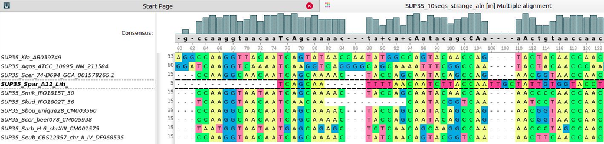

After reverse-complemet operation:

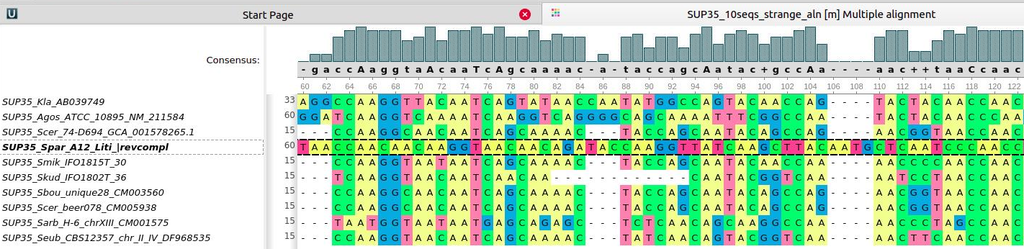

### Launch different alignment algorithms on the file SUP35_250seqs.fa

`SUP35_250seqs.fa` contains 250 sequences of the gene SUP35 from different S. cerevisiae strains

#### ClustalW

```python
! time clustalw -INFILE=SUP35_250seqs.fa -OUTPUT=FASTA -OUTFILE=SUP35_250seqs_clustalw.fa > clustalw_250.log
```

```
1541.83user 0.18system 25:43.73elapsed 99%CPU (0avgtext+0avgdata 13596maxresident)k
4200inputs+4192outputs (20major+3042minor)pagefaults 0swaps
```

```python
record_dict = IO.to_dict(IO.parse("SUP35_250seqs_clustalw.fa", "fasta"))
for key in record_dict.items():
    print(key[0],"\n ", len(key[1].seq))
    break
```

```
SUP35_Scer_T.52_2H_CP007848
  2179
```

#### Muscle

```python
! time muscle -in SUP35_250seqs.fa -out SUP35_250seqs_muscle.fa
```

```
MUSCLE v3.8.1551 by Robert C. Edgar

http://www.drive5.com/muscle
This software is donated to the public domain.
SUP35_250seqs 250 seqs, lengths min 1769, max 2103, avg 2054
00:00:00    19 MB(-2%)  Iter   1  100.00%  K-mer dist pass 1
00:00:00    19 MB(-2%)  Iter   1  100.00%  K-mer dist pass 2
00:00:14  332 MB(-43%)  Iter   1  100.00%  Align node
00:00:14  333 MB(-43%)  Iter   1  100.00%  Root alignment
00:00:19  333 MB(-43%)  Iter   2  100.00%  Refine tree
00:00:19  333 MB(-43%)  Iter   2  100.00%  Root alignment
00:00:19  333 MB(-43%)  Iter   2  100.00%  Root alignment
00:01:02  333 MB(-43%)  Iter   3  100.00%  Refine biparts
00:01:46  333 MB(-43%)  Iter   4  100.00%  Refine biparts
00:01:46  333 MB(-43%)  Iter   5  100.00%  Refine biparts
00:01:46  333 MB(-43%)  Iter   5  100.00%  Refine biparts
105.41user 0.18system 1:45.85elapsed 99%CPU (0avgtext+0avgdata 312612maxresident)k
1152inputs+1168outputs (9major+80479minor)pagefaults 0swaps
```

```python
record_dict = IO.to_dict(IO.parse("SUP35_250seqs_muscle.fa", "fasta"))
for key in record_dict.items():
    print(key[0],"\n ", len(key[1].seq))
    break
```

```
SUP35_Agos_ATCC_10895_NM_211584
  2313
```

#### MAFFT

```python
! time mafft --auto SUP35_250seqs.fa >SUP35_250seqs_mafft.fa
```

```
nthread = 0
nthreadpair = 0
nthreadtb = 0
ppenalty_ex = 0
stacksize: 8192 kb
generating a scoring matrix for nucleotide (dist=200) ... done
Gap Penalty = -1.53, +0.00, +0.00



Making a distance matrix ..

There are 12 ambiguous characters.
  201 / 250
done.

Constructing a UPGMA tree (efffree=0) ...
  240 / 250
done.

Progressive alignment 1/2...
STEP   247 / 249
Reallocating..done. *alloclen = 5227
STEP   249 / 249
done.

Making a distance matrix from msa..
  200 / 250
done.

Constructing a UPGMA tree (efffree=1) ...
  240 / 250
done.

Progressive alignment 2/2...
STEP   247 / 249
Reallocating..done. *alloclen = 5227
STEP   249 / 249
done.

```

[output cut: 84 more lines]

```


Strategy:
 FFT-NS-i (Standard)
 Iterative refinement method (max. 2 iterations)

If unsure which option to use, try 'mafft --auto input > output'.
For more information, see 'mafft --help', 'mafft --man' and the mafft page.

The default gap scoring scheme has been changed in version 7.110 (2013 Oct).
It tends to insert more gaps into gap-rich regions than previous versions.
To disable this change, add the --leavegappyregion option.

17.33user 0.15system 0:17.49elapsed 99%CPU (0avgtext+0avgdata 60600maxresident)k
11584inputs+5040outputs (52major+56496minor)pagefaults 0swaps
```

```python
record_dict = IO.to_dict(IO.parse("SUP35_250seqs_mafft.fa", "fasta"))
for key in record_dict.items():
    print(key[0],"\n ", len(key[1].seq))
    break
```

```
SUP35_Kla_AB039749
  2322
```

#### Kalign

```python
! time kalign <SUP35_250seqs.fa >SUP35_250seqs_kalign.fa
```

```
Kalign version 2.04, Copyright (C) 2004, 2005, 2006 Timo Lassmann

        Kalign is free software. You can redistribute it and/or modify
        it under the terms of the GNU General Public License as
        published by the Free Software Foundation.

reading from STDIN: found 250 sequences
Aligning 250 RNA/DNA sequences with these parameters:
        217.00000000	gap open penalty
        39.40000153	gap extension
        292.60000610	terminal gap penalty
        283.00000000	bonus
Alignment will be written to stdout.

Distance Calculation:
```

[output cut: 254 more lines]

```python
record_dict = IO.to_dict(IO.parse("SUP35_250seqs_kalign.fa", "fasta"))
for key in record_dict.items():
    print(key[0],"\n ", len(key[1].seq))
    break
```

```
SUP35_Kla_AB039749
  2214
```

#### t-coffee

It is too slow to launch it on 250 sequences.

```python
# ! time t_coffee -infile=SUP35_250seqs.fa -outfile=SUP35_250seqs_tcoffee.fa -output=fasta_aln
```

#### Prank

```python
! time prank -d=SUP35_250seqs.fa -o=SUP35_250seqs_prank.fa
```

```
-----------------
 PRANK v.170427:
-----------------

Input for the analysis
 - aligning sequences in 'SUP35_250seqs.fa'
 - using inferred alignment guide tree
 - option '+F' is not used; it can be enabled with '+F'
 - external tools available:
    MAFFT for initial alignment
    Exonerate for alignment anchoring

Correcting (arbitrarily) for multifurcating nodes.
Correcting (arbitrarily) for multifurcating nodes.

Generating multiple alignment: iteration 1.

Alignment score: 9063
Correcting (arbitrarily) for multifurcating nodes.

Generating multiple alignment: iteration 2.

Alignment score: 7787
Correcting (arbitrarily) for multifurcating nodes.

Generating multiple alignment: iteration 3.

Alignment score: 8220
Correcting (arbitrarily) for multifurcating nodes.

Generating multiple alignment: iteration 4.

Alignment score: 7867
Correcting (arbitrarily) for multifurcating nodes.

Generating multiple alignment: iteration 5.

Alignment score: 7869


Writing
 - alignment to 'SUP35_250seqs_prank.fa.best.fas'

Analysis done. Total time 119s

116.98user 1.16system 1:59.50elapsed 98%CPU (0avgtext+0avgdata 66236maxresident)k
0inputs+16704outputs (0major+629152minor)pagefaults 0swaps
```

```python
record_dict = IO.to_dict(IO.parse("SUP35_250seqs_prank.fa.best.fas", "fasta"))
for key in record_dict.items():
    print(key[0],"\n ", len(key[1].seq))
    break
```

```
SUP35_Agos_ATCC_10895_NM_211584
  2472
```

### Compare algorithms on 250 sequences

| algorithm | alignment length (nt) | time (seconds) |
| --- | --- | --- |
| ClustalW | 2179 | 1552.93 |
| MUSCLE | 2313 | 93.33 |
| MAFFT | 2322 | 15.11 |
| Kalign | 2214 | 15.07 |
| t-coffee | - | - |
| prank | 2472 | 102.53 |

### Translation into amino acids

```python
# sudo apt-get update -y
# sudo apt-get install -y emboss
```

**Transeq** translates nucleotide sequence into amino acids just directly reading codons

```python
! transeq -sequence SUP35_10seqs.fa -outseq SUP35_10seqs.t.faa
```

```
Translate nucleic acid sequences
```

```python
! head -20 SUP35_10seqs.t.faa
```

```
>SUP35_Kla_AB039749_1
MSDQQNQDQGQGQGYNQYNQYGQYNQYYNQQGYQGYNGQQGAPQGYQAYQAYGQQPQGAY
QGYNPQQAQGYQPYQGYNAQQQGYNAQQGGHNNNYNKNYNNKNSYNNYNKQGYQGAQGYN
AQQPTGYAAPAQSSSQGMTLKDFQNQQGSTNAAKPKPKLKLASSSGIKLVGAKKPVAPKT
EKTDESKEATKTTDDNEEAQSELPKIDDLKISEAEKPKTKENTPSADDTSSEKTTSAKAD
TSTGGANSVDALIKEQEDEVDEEVVKDMFGGKDHVSIIFMGHVDAGKSTMGGNLLYLTGS
VDKRTVEKYEREAKEAGRQGWYLSWVMDTNKEERNDGKTIEVGRAYFETEKRRYTILDAP
GHKMYVSEMIGGASQADIGILVISARKGEYETGFEKGGQTREHALLAKTQGVNKMIVVIN
KMDDPTVGWDKERYDHCVGNLTNFLKAVGYNVKEDVIFMPVSGYTGAGLKERVDPKDCPW
YTGPSLLEYLDNMKTTDRHINAPFMLPIASKMKDMGTVVEGKIESGHIRKGNQTLLMPNR
TSVEILTIYNETESEVDMAVCGEQVRLRIKGVEEEEISAGFVLTSPKNPVKNVTRFVAQI
AIVELKSIMSAGFSCVMHIHTAIEEVTVTRLLHKLEKGSNRKSKKPPAFAKKGMKIIAVI
ETNEPVCVETYDDYPQLGRFTLRDQGTTIAIGKIVKILEN*
>SUP35_Agos_ATCC_10895_NM_211584_1
MSEEDQIQSQGNDQGQSQAKDQGQNQGQGQQNFGQYYNPSNFQNYQGYVPQGGYQAYGQQ
AGGYQGYAQYNQQAGGYQGYQGYQQYNPAQAGYQGYQQYNAQGGYQSYKQYNSQPQGNRK
GNQSYGYGQGQSATAPVTLNNFEKGTVPNATAPKPKKTLKLASSSGIKLVGAKKPVAKKE
EAKAEEPTKEEPKSSAEGAPKSEDATASSEDKAVPSIEKLSISEADTAKKDTADAAGATS
SDALIKEQEDEVDEEVVKDMFGGKDHVSIIFMGHVDAGKSTMGGNLLYLTGSVDKRTVEK
YEKEAKEAGRQGWYLSWIMDTNKEERNDGKTIEVGRSYFETEKRRYTILDAPGHKMYVSE
```

**Getorf** searches for ORFs in an input file and then outputs them.

`-minsize`: minimum size of ORF (otherwise it will output too many ORFs per sequence and most of them will be a garbage)

```python
! getorf -sequence SUP35_10seqs.fa -outseq SUP35_10seqs.g.faa -noreverse -minsize 500
```

```
Find and extract open reading frames (ORFs)
```

[...] - coordinates of ORFs

```python
! head -20 SUP35_10seqs.g.faa
```

```
>SUP35_Kla_AB039749_1 [1 - 2100]
MSDQQNQDQGQGQGYNQYNQYGQYNQYYNQQGYQGYNGQQGAPQGYQAYQAYGQQPQGAY
QGYNPQQAQGYQPYQGYNAQQQGYNAQQGGHNNNYNKNYNNKNSYNNYNKQGYQGAQGYN
AQQPTGYAAPAQSSSQGMTLKDFQNQQGSTNAAKPKPKLKLASSSGIKLVGAKKPVAPKT
EKTDESKEATKTTDDNEEAQSELPKIDDLKISEAEKPKTKENTPSADDTSSEKTTSAKAD
TSTGGANSVDALIKEQEDEVDEEVVKDMFGGKDHVSIIFMGHVDAGKSTMGGNLLYLTGS
VDKRTVEKYEREAKEAGRQGWYLSWVMDTNKEERNDGKTIEVGRAYFETEKRRYTILDAP
GHKMYVSEMIGGASQADIGILVISARKGEYETGFEKGGQTREHALLAKTQGVNKMIVVIN
KMDDPTVGWDKERYDHCVGNLTNFLKAVGYNVKEDVIFMPVSGYTGAGLKERVDPKDCPW
YTGPSLLEYLDNMKTTDRHINAPFMLPIASKMKDMGTVVEGKIESGHIRKGNQTLLMPNR
TSVEILTIYNETESEVDMAVCGEQVRLRIKGVEEEEISAGFVLTSPKNPVKNVTRFVAQI
AIVELKSIMSAGFSCVMHIHTAIEEVTVTRLLHKLEKGSNRKSKKPPAFAKKGMKIIAVI
ETNEPVCVETYDDYPQLGRFTLRDQGTTIAIGKIVKILEN
>SUP35_Agos_ATCC_10895_NM_211584_1 [1 - 2073]
MSEEDQIQSQGNDQGQSQAKDQGQNQGQGQQNFGQYYNPSNFQNYQGYVPQGGYQAYGQQ
AGGYQGYAQYNQQAGGYQGYQGYQQYNPAQAGYQGYQQYNAQGGYQSYKQYNSQPQGNRK
GNQSYGYGQGQSATAPVTLNNFEKGTVPNATAPKPKKTLKLASSSGIKLVGAKKPVAKKE
EAKAEEPTKEEPKSSAEGAPKSEDATASSEDKAVPSIEKLSISEADTAKKDTADAAGATS
SDALIKEQEDEVDEEVVKDMFGGKDHVSIIFMGHVDAGKSTMGGNLLYLTGSVDKRTVEK
YEKEAKEAGRQGWYLSWIMDTNKEERNDGKTIEVGRSYFETEKRRYTILDAPGHKMYVSE
```

### Protein alignments

#### ClustalW

`-TYPE`: specifies a type of the sequence.  
Other algorithms can identify it automatically just reading the first letters of input sequences

```python
! time clustalw -INFILE=SUP35_10seqs.g.faa -OUTFILE=SUP35_10seqs_clustalw.faa -OUTPUT=FASTA -TYPE=protein
```

```
 CLUSTAL 2.1 Multiple Sequence Alignments


Sequence type explicitly set to Protein
Sequence format is Pearson
Sequence 1: SUP35_Kla_AB039749_1                       700 aa
Sequence 2: SUP35_Agos_ATCC_10895_NM_211584_1          691 aa
Sequence 3: SUP35_Scer_74-D694_GCA_001578265.1_1       685 aa
Sequence 4: SUP35_Spar_A12_Liti_1                      681 aa
Sequence 5: SUP35_Smik_IFO1815T_30_1                   681 aa
Sequence 6: SUP35_Skud_IFO1802T_36_1                   678 aa
Sequence 7: SUP35_Sbou_unique28_CM003560_1             685 aa
Sequence 8: SUP35_Scer_beer078_CM005938_1              666 aa
Sequence 9: SUP35_Sarb_H-6_chrXIII_CM001575_1          680 aa
Sequence 10: SUP35_Seub_CBS12357_chr_II_IV_DF968535_1   674 aa
Start of Pairwise alignments
Aligning...

Sequences (1:2) Aligned. Score:  71
Sequences (1:3) Aligned. Score:  69
Sequences (1:4) Aligned. Score:  69
Sequences (1:5) Aligned. Score:  68
Sequences (1:6) Aligned. Score:  68
Sequences (1:7) Aligned. Score:  69
Sequences (1:8) Aligned. Score:  70
Sequences (1:9) Aligned. Score:  67
Sequences (1:10) Aligned. Score:  69
Sequences (2:3) Aligned. Score:  68
Sequences (2:4) Aligned. Score:  69
Sequences (2:5) Aligned. Score:  70
Sequences (2:6) Aligned. Score:  69
Sequences (2:7) Aligned. Score:  69
Sequences (2:8) Aligned. Score:  71
Sequences (2:9) Aligned. Score:  67
Sequences (2:10) Aligned. Score:  69
Sequences (3:4) Aligned. Score:  97
Sequences (3:5) Aligned. Score:  94
Sequences (3:6) Aligned. Score:  92
Sequences (3:7) Aligned. Score:  99
Sequences (3:8) Aligned. Score:  99
```

[output cut: 31 more lines]

```
Group 3: Sequences:   4      Score:14367
Group 4: Sequences:   5      Score:14254
Group 5: Sequences:   6      Score:14159
Group 6: Sequences:   7      Score:14064
Group 7: Sequences:   8      Score:13830
Group 8: Sequences:   2      Score:12740
Group 9: Sequences:  10      Score:11985
Alignment Score 155481
firstres = 1 lastres = 719
FASTA file created!

Fasta-Alignment file created    [SUP35_10seqs_clustalw.faa]

0.39user 0.00system 0:00.39elapsed 100%CPU (0avgtext+0avgdata 4852maxresident)k
0inputs+24outputs (0major+298minor)pagefaults 0swaps
```

```python
! head -20 SUP35_10seqs_clustalw.faa
```

```
>SUP35_Scer_74-D694_GCA_001578265.1_1
MSDSN----QGNNQQNYQQYSQNGNQQQG----NNRY--Q
GYQAYNAQAQ-PAGGYYQNYQGYSGYQQGGY----QQYNP
DAGYQQQYNPQGGYQQYNP-QGGYQQ----QFNPQGGRGN
YKNFNYNNNLQ-------GYQAGFQPQSQGMSLNDFQK--
QQKQAAPKPKKTLKLVSSSGIKLANATKKVGTKPAESDKK
EEEKSAETKEPTKEPTKVEEPVKKEEKPVQTEEKTEEKSE
LPKVEDLKISEST----HNTNNANVTSADALIKEQEEEVD
DEVVNDMFGGKDHVSLIFMGHVDAGKSTMGGNLLYLTGSV
DKRTIEKYEREAKDAGRQGWYLSWVMDTNKEERNDGKTIE
VGKAYFETEKRRYTILDAPGHKMYVSEMIGGASQADVGVL
VISARKGEYETGFERGGQTREHALLAKTQGVNKMVVVVNK
MDDPTVNWSKERYDQCVSNVSNFLRAIGYNIKTDVVFMPV
SGYSGANLKDHVDPKECPWYTGPTLLEYLDTMNHVDRHIN
APFMLPIAAKMKDLGTIVEGKIESGHIKKGQSTLLMPNKT
AVEIQNIYNETENEVDMAMCGEQVKLRIKGVEEEDISPGF
VLTSPKNPIKSVTKFVAQIAIVELKSIIAAGFSCVMHVHT
AIEEVHIVKLLHKLEKGTNRKSKKPPAFAKKGMKVIAVLE
TEAPVCVETYQDYPQLGRFTLRDQGTTIAIGKIVKIAE-
>SUP35_Scer_beer078_CM005938_1
```

```python
record_dict = IO.to_dict(IO.parse("SUP35_10seqs_clustalw.faa", "fasta"))
for key in record_dict.items():
    print(key[0],"\n ", len(key[1].seq))
```

```
SUP35_Scer_74-D694_GCA_001578265.1_1
  719
SUP35_Scer_beer078_CM005938_1
  719
SUP35_Sbou_unique28_CM003560_1
  719
SUP35_Spar_A12_Liti_1
  719
SUP35_Smik_IFO1815T_30_1
  719
SUP35_Sarb_H-6_chrXIII_CM001575_1
  719
SUP35_Skud_IFO1802T_36_1
  719
SUP35_Seub_CBS12357_chr_II_IV_DF968535_1
  719
SUP35_Kla_AB039749_1
  719
SUP35_Agos_ATCC_10895_NM_211584_1
  719
```

#### Clustal Omega

```python
! time clustalo --infile=SUP35_10seqs.g.faa --outfile=SUP35_10seqs_clustalo.faa --verbose
```

```
Using 8 threads
Read 10 sequences (type: Protein) from SUP35_10seqs.g.faa
not more sequences (10) than cluster-size (100), turn off mBed
Calculating pairwise ktuple-distances...
Ktuple-distance calculation progress done. CPU time: 0.11u 0.00s 00:00:00.11 Elapsed: 00:00:00
Guide-tree computation done.
Progressive alignment progress done. CPU time: 1.05u 0.03s 00:00:01.08 Elapsed: 00:00:00
Alignment written to SUP35_10seqs_clustalo.faa
1.16user 0.03system 0:00.48elapsed 251%CPU (0avgtext+0avgdata 32988maxresident)k
1784inputs+16outputs (11major+44463minor)pagefaults 0swaps
```

```python
record_dict = IO.to_dict(IO.parse("SUP35_10seqs_clustalo.faa", "fasta"))
for key in record_dict.items():
    print(key[0],"\n ", len(key[1].seq))
```

```
SUP35_Kla_AB039749_1
  757
SUP35_Agos_ATCC_10895_NM_211584_1
  757
SUP35_Scer_74-D694_GCA_001578265.1_1
  757
SUP35_Spar_A12_Liti_1
  757
SUP35_Smik_IFO1815T_30_1
  757
SUP35_Skud_IFO1802T_36_1
  757
SUP35_Sbou_unique28_CM003560_1
  757
SUP35_Scer_beer078_CM005938_1
  757
SUP35_Sarb_H-6_chrXIII_CM001575_1
  757
SUP35_Seub_CBS12357_chr_II_IV_DF968535_1
  757
```

#### Muscle

```python
! time muscle -in SUP35_10seqs.g.faa -out SUP35_10seqs_muscle.faa
```

```
MUSCLE v3.8.1551 by Robert C. Edgar

http://www.drive5.com/muscle
This software is donated to the public domain.
SUP35_10seqs.g 10 seqs, lengths min 666, max 700, avg 682
00:00:00    15 MB(-2%)  Iter   1  100.00%  K-mer dist pass 1
00:00:00    15 MB(-2%)  Iter   1  100.00%  K-mer dist pass 2
00:00:01    22 MB(-3%)  Iter   1  100.00%  Align node
00:00:01    22 MB(-3%)  Iter   1  100.00%  Root alignment
00:00:01    22 MB(-3%)  Iter   2  100.00%  Refine tree
00:00:01    22 MB(-3%)  Iter   2  100.00%  Root alignment
00:00:01    22 MB(-3%)  Iter   2  100.00%  Root alignment
00:00:01    22 MB(-3%)  Iter   3  100.00%  Refine biparts
00:00:01    22 MB(-3%)  Iter   4  100.00%  Refine biparts
00:00:01    22 MB(-3%)  Iter   5  100.00%  Refine biparts
00:00:01    22 MB(-3%)  Iter   5  100.00%  Refine biparts
00:00:01    22 MB(-3%)  Iter   6  100.00%  Refine biparts
00:00:01    22 MB(-3%)  Iter   7  100.00%  Refine biparts
00:00:01    22 MB(-3%)  Iter   8  100.00%  Refine biparts
00:00:01    22 MB(-3%)  Iter   8  100.00%  Refine biparts
00:00:01    22 MB(-3%)  Iter   9  100.00%  Refine biparts
00:00:01    22 MB(-3%)  Iter  10  100.00%  Refine biparts
00:00:01    22 MB(-3%)  Iter  11  100.00%  Refine biparts
00:00:01    22 MB(-3%)  Iter  12  100.00%  Refine biparts
00:00:01    22 MB(-3%)  Iter  13  100.00%  Refine biparts
00:00:01    22 MB(-3%)  Iter  13  100.00%  Refine biparts
00:00:01    22 MB(-3%)  Iter  14  100.00%  Refine biparts
00:00:01    22 MB(-3%)  Iter  15  100.00%  Refine biparts
00:00:01    22 MB(-3%)  Iter  16  100.00%  Refine biparts
00:00:01    22 MB(-3%)  Iter  17  100.00%  Refine biparts
00:00:01    22 MB(-3%)  Iter  18  100.00%  Refine biparts
00:00:01    22 MB(-3%)  Iter  19  100.00%  Refine biparts
00:00:01    22 MB(-3%)  Iter  20  100.00%  Refine biparts
00:00:01    22 MB(-3%)  Iter  21  100.00%  Refine biparts
00:00:01    22 MB(-3%)  Iter  22  100.00%  Refine biparts
00:00:01    22 MB(-3%)  Iter  23  100.00%  Refine biparts
00:00:01    22 MB(-3%)  Iter  24  100.00%  Refine biparts
00:00:01    22 MB(-3%)  Iter  25  100.00%  Refine biparts
00:00:01    22 MB(-3%)  Iter  26  100.00%  Refine biparts
0.15user 0.00system 0:00.15elapsed 99%CPU (0avgtext+0avgdata 10784maxresident)k
0inputs+16outputs (0major+2094minor)pagefaults 0swaps
```

```python
record_dict = IO.to_dict(IO.parse("SUP35_10seqs_muscle.faa", "fasta"))
for key in record_dict.items():
    print(key[0],"\n ", len(key[1].seq))
```

```
SUP35_Kla_AB039749_1
  743
SUP35_Agos_ATCC_10895_NM_211584_1
  743
SUP35_Seub_CBS12357_chr_II_IV_DF968535_1
  743
SUP35_Skud_IFO1802T_36_1
  743
SUP35_Sarb_H-6_chrXIII_CM001575_1
  743
SUP35_Smik_IFO1815T_30_1
  743
SUP35_Spar_A12_Liti_1
  743
SUP35_Scer_74-D694_GCA_001578265.1_1
  743
SUP35_Sbou_unique28_CM003560_1
  743
SUP35_Scer_beer078_CM005938_1
  743
```

#### MAFFT

```python
! time mafft --auto SUP35_10seqs.g.faa >SUP35_10seqs_mafft.faa
```

```
outputhat23=16
treein = 0
compacttree = 0
stacksize: 8192 kb
rescale = 1
All-to-all alignment.
tbfast-pair (aa) Version 7.453
alg=L, model=BLOSUM62, 2.00, -0.10, +0.10, noshift, amax=0.0
0 thread(s)

outputhat23=16
Loading 'hat3.seed' ...
done.
Writing hat3 for iterative refinement
rescale = 1
Gap Penalty = -1.53, +0.00, +0.00
tbutree = 1, compacttree = 0
Constructing a UPGMA tree ...
    0 / 10
done.

Progressive alignment ...
STEP     8 /9
Reallocating..done. *alloclen = 2413
STEP     9 /9
done.
tbfast (aa) Version 7.453
alg=A, model=BLOSUM62, 1.53, -0.00, -0.00, noshift, amax=0.0
1 thread(s)

minimumweight = 0.000010
autosubalignment = 0.000000
nthread = 0
randomseed = 0
blosum 62 / kimura 200
poffset = 0
niter = 16
sueff_global = 0.100000
nadd = 16
Loading 'hat3' ... done.
```

[output cut: 11 more lines]

```


Strategy:
 L-INS-i (Probably most accurate, very slow)
 Iterative refinement method (<16) with LOCAL pairwise alignment information

If unsure which option to use, try 'mafft --auto input > output'.
For more information, see 'mafft --help', 'mafft --man' and the mafft page.

The default gap scoring scheme has been changed in version 7.110 (2013 Oct).
It tends to insert more gaps into gap-rich regions than previous versions.
To disable this change, add the --leavegappyregion option.

0.41user 0.03system 0:00.40elapsed 111%CPU (0avgtext+0avgdata 14484maxresident)k
1256inputs+152outputs (9major+30851minor)pagefaults 0swaps
```

```python
record_dict = IO.to_dict(IO.parse("SUP35_10seqs_mafft.faa", "fasta"))
for key in record_dict.items():
    print(key[0],"\n ", len(key[1].seq))
```

```
SUP35_Kla_AB039749_1
  759
SUP35_Agos_ATCC_10895_NM_211584_1
  759
SUP35_Scer_74-D694_GCA_001578265.1_1
  759
SUP35_Spar_A12_Liti_1
  759
SUP35_Smik_IFO1815T_30_1
  759
SUP35_Skud_IFO1802T_36_1
  759
SUP35_Sbou_unique28_CM003560_1
  759
SUP35_Scer_beer078_CM005938_1
  759
SUP35_Sarb_H-6_chrXIII_CM001575_1
  759
SUP35_Seub_CBS12357_chr_II_IV_DF968535_1
  759
```

#### Kalign

```python
! time kalign <SUP35_10seqs.g.faa >SUP35_10seqs_kalign.faa
```

```
Kalign version 2.04, Copyright (C) 2004, 2005, 2006 Timo Lassmann

        Kalign is free software. You can redistribute it and/or modify
        it under the terms of the GNU General Public License as
        published by the Free Software Foundation.

reading from STDIN: found 10 sequences
Aligning 10 protein sequences with these parameters:
        54.94940948	gap open penalty
        8.52492046	gap extension
        4.42409992	terminal gap penalty
        0.20000000	bonus
Alignment will be written to stdout.

Distance Calculation:
     100 percent done
Alignment:
     100 percent done
0.03user 0.00system 0:00.04elapsed 90%CPU (0avgtext+0avgdata 2888maxresident)k
0inputs+16outputs (0major+594minor)pagefaults 0swaps
```

```python
record_dict = IO.to_dict(IO.parse("SUP35_10seqs_kalign.faa", "fasta"))
for key in record_dict.items():
    print(key[0],"\n ", len(key[1].seq))
```

```
SUP35_Kla_AB039749_1
  720
SUP35_Agos_ATCC_10895_NM_211584_1
  720
SUP35_Scer_74-D694_GCA_001578265.1_1
  720
SUP35_Spar_A12_Liti_1
  720
SUP35_Smik_IFO1815T_30_1
  720
SUP35_Skud_IFO1802T_36_1
  720
SUP35_Sbou_unique28_CM003560_1
  720
SUP35_Scer_beer078_CM005938_1
  720
SUP35_Sarb_H-6_chrXIII_CM001575_1
  720
SUP35_Seub_CBS12357_chr_II_IV_DF968535_1
  720
```

#### t-coffee

```python
! time t_coffee -infile=SUP35_10seqs.g.faa -outfile=SUP35_10seqs_tcoffee.faa -output=fasta_aln
```

[output not shown]

[output cut: 389 more lines]

```
OUTPUT RESULTS
	#### File Type= GUIDE_TREE      Format= newick          Name= SUP35_10seqs.g.dnd
	#### File Type= MSA             Format= fasta_aln       Name= SUP35_10seqs_tcoffee.faa

# Command Line: /home/isemenov/anaconda3/lib/t_coffee-11.0.8/bin/t_coffee -infile SUP35_10seqs.g.faa -outfile SUP35_10seqs_tcoffee.faa -output fasta_aln  [PROGRAM:T-COFFEE]
# T-COFFEE Memory Usage: Current= 30.926 Mb, Max= 34.044 Mb
# Results Produced with T-COFFEE Version_11.00.8cbe486 (2014-08-12 22:05:29 - Revision 8cbe486 - Build 477)
# T-COFFEE is available from http://www.tcoffee.org
# Register on: https://groups.google.com/group/tcoffee/

Result: None
Error message: None

32.24user 0.42system 0:05.24elapsed 622%CPU (0avgtext+0avgdata 119936maxresident)k
12912inputs+9048outputs (28major+188267minor)pagefaults 0swaps
```

```python
record_dict = IO.to_dict(IO.parse("SUP35_10seqs_tcoffee.faa", "fasta"))
for key in record_dict.items():
    print(key[0],"\n ", len(key[1].seq))
```

```
SUP35_Kla_AB039749_1
  752
SUP35_Agos_ATCC_10895_NM_211584_1
  752
SUP35_Scer_74-D694_GCA_001578265.1_1
  752
SUP35_Spar_A12_Liti_1
  752
SUP35_Smik_IFO1815T_30_1
  752
SUP35_Skud_IFO1802T_36_1
  752
SUP35_Sbou_unique28_CM003560_1
  752
SUP35_Scer_beer078_CM005938_1
  752
SUP35_Sarb_H-6_chrXIII_CM001575_1
  752
SUP35_Seub_CBS12357_chr_II_IV_DF968535_1
  752
```

#### Prank

```python
! time prank -d=SUP35_10seqs.g.faa -o=SUP35_10seqs_prank.faa
```

```
-----------------
 PRANK v.170427:
-----------------

Input for the analysis
 - aligning sequences in 'SUP35_10seqs.g.faa'
 - using inferred alignment guide tree
 - option '+F' is not used; it can be enabled with '+F'
 - external tools available:
    MAFFT for initial alignment
    Exonerate for alignment anchoring

Warning: sequence names changed.

Correcting (arbitrarily) for multifurcating nodes.
Correcting (arbitrarily) for multifurcating nodes.

Generating multiple alignment: iteration 1.

Alignment score: 1285
Correcting (arbitrarily) for multifurcating nodes.

Generating multiple alignment: iteration 2.

Alignment score: 1297
Correcting (arbitrarily) for multifurcating nodes.

Generating multiple alignment: iteration 3.

Alignment score: 1292
Correcting (arbitrarily) for multifurcating nodes.

Generating multiple alignment: iteration 4.

Alignment score: 1292
Correcting (arbitrarily) for multifurcating nodes.

Generating multiple alignment: iteration 5.

Alignment score: 1292


Writing
 - alignment to 'SUP35_10seqs_prank.faa.best.fas'

Analysis done. Total time 9s

8.86user 0.14system 0:09.03elapsed 99%CPU (0avgtext+0avgdata 23516maxresident)k
0inputs+416outputs (1major+97565minor)pagefaults 0swaps
```

```python
record_dict = IO.to_dict(IO.parse("SUP35_10seqs_prank.faa.best.fas", "fasta"))
for key in record_dict.items():
    print(key[0],"\n ", len(key[1].seq))
```

```
SUP35_Kla_AB039749_1_[1_-_2100]
  791
SUP35_Agos_ATCC_10895_NM_211584_1_[1_-_2073]
  791
SUP35_Scer_74-D694_GCA_001578265.1_1_[1_-_2055]
  791
SUP35_Sbou_unique28_CM003560_1_[1_-_2055]
  791
SUP35_Scer_beer078_CM005938_1_[1_-_1998]
  791
SUP35_Spar_A12_Liti_1_[1_-_2043]
  791
SUP35_Smik_IFO1815T_30_1_[1_-_2043]
  791
SUP35_Sarb_H-6_chrXIII_CM001575_1_[1_-_2040]
  791
SUP35_Skud_IFO1802T_36_1_[1_-_2034]
  791
SUP35_Seub_CBS12357_chr_II_IV_DF968535_1_[1_-_2022]
  791
```

### Compare algorithms on 10 protein sequences

| algorithm | alignment length (nt) | time (seconds) |
| --- | --- | --- |
| ClustalW | 719 | 0.38 |
| CLustalO | 757 | 1.22 |
| MUSCLE | 743 | 0.16 |
| MAFFT | 759 | 0.37 |
| Kalign | 720 | 0.04 |
| t-coffee | 752 | 31.96 |
| prank | 791 | 9.91 |

**Conslusion:** the best algorithm here is **MAFFT**. It has rather good length of alignment and speed (balance between these two metrics)

### Adding sequences to alignments

MAFFT and Muscle allows to add new sequences to existing alignments without their recalculations

```python
! cat SUP35_2addseqs.fa
```

```
>SUP35_Scer_beer090_CM005746
ATGTCGGATTCAAACCAAGGCAACAATCAGCAAAACTACCAGCAATACAGCCAGAACGGTAACCAACAAC
AAGGTAACAACAGATACCAAGGTTATCAAGCTTACAATGCTCAAGCCCAACCTGCAGGTGGGTACTACCA
AAATTACCAAGGTTATTCTGGGTACCAACAAGGTGGCTATCAACAGTACAATCCCGACGCCGGTTACCAG
CAACAGTATAATCCTCAAGGAGGCTATCAACAGTACAATCCTCAAGGCGGTTATCAGCAGCAATTCAATC
CACAAGGTGGCCGTGGAAATTACAAAAACTTCAACTACAATAACAATTTGCAAGGATATCAAGCTGGTTT
CCAACCACAGTCTCAAGGTATGTCTTTGAACGACTTTCAAAAGCAACAAAAGCAGGCCGCTCCCAAACCA
AAGAAGACTTTGAAGCTTGTCTCCAGTTCCGGTATCAAGTTGGCCAATGCTACCAAGAAGGTTGACACAA
AACCTGCCGAATCTGATAAGAAAGAGGAAGAGAAGTCTGCTGAAACCAAAGAACCAACTAAAGAGCCAAC
AAAGGTCGAAGAACCAGTTAAAAAGGAGGAGAAACCAGTCCAGACTGAAGAAAAGACGGAGGAAAAATCG
GAACTTCCAAAGGTAGAAGACCTTAAAATCTCTGAATCAACACATAATACCAACAATGCCAATGTTACCA
GTGCTGATGCCTTGATCAAGGAACAGGAAGAAGAAGTGGATGACGAAGTTGTTAACGATATGTTTGGTGG
TAAAGATCACGTTTCTTTAATTTTCATGGGTCATGTTGATGCCGGTAAATCTACTATGGGTGGTAATCTA
CTATACTTGACTGGCTCTGTGGATAAGAGAACTATTGAGAAATATGAAAGAGAAGCCAAGGATGCAGGCA
GACAAGGTTGGTACTTGTCATGGGTCATGGATACCAACAAAGAAGAAAGAAATGATGGTAAGACTATCGA
AGTTGGTAAGGCCTACTTTGAAACTGAAAAAAGGCGTTATACCATATTGGATGCTCCTGGTCATAAAATG
TACGTTTCCGAGATGATCGGTGGTGCTTCTCAAGCTGATGTTGGTGTTTTGGTCATTTCCGCCAGAAAGG
GTGAGTACGAAACCGGTTTTGAGAGAGGTGGTCAAACTCGTGAACACGCCCTATTGGCCAAGACCCAAGG
TGTTAATAAGATGGTTGTCGTCGTAAATAAGATGGATGACCCAACCGTTAACTGGTCTAAGGAACGTTAC
GACCAATGTGTGAGTAATGTCAGCAATTTCTTGAGAGCAATTGGTTACAACATTAAGACAGACGTTGTAT
TTATGCCAGTATCCGGCTACAGTGGTGCAAATTTGAAAGATCACGTAGATCCAAAAGAATGCCCATGGTA
CACCGGCCCAACTCTGTTAGAATATCTGGATACAATGAACCACGTCGACCGTCACATCAATGCTCCATTC
ATGTTGCCTATTGCCGCTAAGATGAAGGATCTAGGTACCATCGTTGAAGGTAAAATTGAATCCGGTCATA
TCAAAAAGGGTCAATCCACCCTACTGATGCCTAACAAAACCGCTGTGGAAATTCAAAATATTTACAACGA
AACTGAAAATGAAGTTGATATGGCTATGTGTGGTGAGCAAGTTAAACTAAGAATCAAAGGTGTTGAAGAA
GAAGACATTTCACCAGGTTTTGTACTAACATCGCCAAAGAACCCTATCAAGAGTGTTACCAAGTTTGTAG
CTCAAATTGCTATTGTAGAATTAAAATCTATCATAGCAGCCGGTTTTTCATGTGTTATGCATGTTCATAC
AGCAATTGAAGAGGTACATATTGTTAAGTTATTGCACAAATTAGAAAAGGGTACCAACCGTAAGTCAAAG
AAACCACCTGCTTTTGCTAAGAAGGGTATGAAGGTCATCGCTGTTTTAGAAACTGAAGCTCCAGTTTGTG
TGGAAACTTACCAAGATTACCCTCAATTAGGTAGATTCACTTTGAGAGATCAAGGTACCACAATAGCAAT
TGGTAAAATTGTTAAAATTGCCGAGTAA
>SUP35_Scer_EC1118_FN393063.1
ATGTCGGATTCAAACCAAGGCAACAATCAGCAAAACTACCAGCAATACAGCCAGAACGGTAACCAACAAC
AAGGTAACAACAGATACCAAGGTTATCAAGCTTACAATGCTCAAGCCCAACCTGCAGGTGGGTACTACCA
AAATTACCAAGGTTATTCTGGGTACCAACAAGGTGGCTATCAACAGTACAATCCCGACGCCGGTTACCAG
CAACAGTATAATCCTCAAGGAGGCTATCAACAGTACAATCCTCAAGGCGGTTATCAGCAGCAATTCAATC
CACAAGGTGGCCGTGGAAATTACAAAAACTTCAACTACAATAACAATTTGCAAGGATATCAAGCTGGTTT
CCAACCACAGTCTCAAGGTATGTCTTTGAACGACTTTCAAAAGCAACAAAAGCAGGCCGCTCCCAAACCA
AAGAAGACTTTGAAGCTTGTCTCCAGTTCCGGTATCAAGTTGGCCAATGCTACCAAGAAGGTTGACACAA
AACCTGCCGAATCTGAAAAGAAAGAGGAAGAGAAGTCTGCTGAAACCAAAGAACCAACTAAAGAGCCAAC
AAAGGTCGAAGAACCAGTTAAAAAGGAGGAGAAACCAGTCCAGACTGAAGAAAAGAAGGAGGAAAAATCG
GAACTTCCAAAGGTAGAAGACCTCAAAATCTCTGAATCAACACATAATACCAACAATGCCAATGTTACCA
GTGCTGATGCCTTGATCAAGGAACAGGAAGAAGAAGTGGATGACGAAGTTGTTAACGATATGTTTGGTGG
TAAAGATCACGTTTCTTTAATTTTCATGGGTCATGTTGATGCCGGTAAATCTACTATGGGTGGTAATCTA
CTATACTTGACTGGCTCTGTGGATAAGAGAACTATTGAGAAATATGAAAGAGAAGCCAAGGATGCAGGCA
GACAAGGTTGGTACTTGTCATGGGTCATGGATACCAACAAAGAAGAAAGAAATGATGGTAAGACTATCGA
AGTTGGTAAGGCCTACTTTGAAACTGAAAAAAGGCGTTATACCATATTGGATGCTCCTGGTCATAAAATG
TACGTTTCCGAGATGATCGGTGGTGCTTCTCAAGCTGATGTTGGTGTTTTGGTCATTTCCGCCAGAAAGG
GTGAGTACGAAACCGGTTTTGAGAGAGGTGGTCAAACTCGTGAACACGCCCTATTGGCCAAGACCCAAGG
TGTTAATAAGATGGCTGTCGTCGTAAATAAGATGGATGACCCAACCGTTAACTGGTCTAAGGAACGTTAC
GACCAATGTGTGAGTAATGTCAGCAATTTCTTGAGAGCAATTGGTTACAACATTAAGACAGACGTTGTAT
TTATGCCAGTATCCGGCTACAGTGGTGCAAATTTGAAAGATCACGTAGATCCAAAAGAATGCCCATGGTA
CACCGGCCCAACTCTGTTAGAATATCTGGATACAATGAACCACGTCGACCGTCACATCAATGCTCCATTC
ATGTTGCCTATTGCCGCTAAGATGAAGGATCTAGGTACCATCGTTGAAGGTAAAATTGAATCCGGTCATA
TCAAAAAGGGTCAATCCACCCTACTGATGCCTAACAAAACCGCTGTGGAAATTCAAAATATTTACAACGA
AACTGAAAATGAAGTTGATATGGCTATGTGTGGTGAGCAAGTTAAACTAAGAATCAAAGGTGTTGAAGAA
GAAGACATTTCACCAGGTTTTGTACTAACATCGCCAAAGAACCCTATCAAGAGTGTTACCAAGTTTGTAG
CTCAAATTGCTATTGTAGAATTAAAATCTATCATAGCAGCCGGTTTTTCATGTGTTATGCATGTTCATAC
AGCAATTGAAGAGGTACATATTGTTAAGTTATTGCACAAATTAGAAAAGGGTACCAACCGTAAGTCAAAG
AAACCACCTGCTTTTGCTAAGAAGGGTATGAAGGTCATCGCTGTTTTAGAAACTGAAGCTCCAGTTTGTG
TGGAAACTTACCAAGATTACCCTCAATTAGGTAGATTCACTTTGAGAGATCAAGGTACCACAATAGCAAT
TGGTAAAATTGTTAAAATTGCCGAGTAA
```

Firstly, we align these two sequences to each other

```python
! muscle -in SUP35_2addseqs.fa -out SUP35_2addseqs_muscle.fa
```

```
MUSCLE v3.8.1551 by Robert C. Edgar

http://www.drive5.com/muscle
This software is donated to the public domain.
SUP35_2addseqs 2 seqs, lengths min 2058, max 2058, avg 2058
00:00:00    15 MB(-2%)  Iter   1  100.00%  K-mer dist pass 1
00:00:00    15 MB(-2%)  Iter   1  100.00%  K-mer dist pass 2
00:00:00    27 MB(-3%)  Iter   1  100.00%  Align node
00:00:00    27 MB(-3%)  Iter   1  100.00%  Root alignment
```

And then add them to existing alignments of our 250 sequences

```python
! muscle -profile -in1 SUP35_250seqs_muscle.fa -in2 SUP35_2addseqs.fa -out SUP35_252seqs_muscle.fa
```

```
MUSCLE v3.8.1551 by Robert C. Edgar

http://www.drive5.com/muscle
This software is donated to the public domain.
00:00:00    15 MB(-2%)  Reading SUP35_250seqs_muscle.fa
00:00:00    17 MB(-2%)  250 seqs 2313 cols
00:00:00    17 MB(-2%)  Reading SUP35_2addseqs.fa
00:00:00    17 MB(-2%)  2 seqs 2058 cols
00:00:01    18 MB(-2%)  Aligning profiles
00:00:01    29 MB(-4%)  Building output
00:00:01    30 MB(-4%)  Writing output
```

Similiar procedure can be done with MAFFT

```python
! mafft --auto SUP35_2addseqs.fa > SUP35_2addseqs_mafft.fa
```

```
outputhat23=16
treein = 0
compacttree = 0
stacksize: 8192 kb
generating a scoring matrix for nucleotide (dist=200) ... done
All-to-all alignment.
tbfast-pair (nuc) Version 7.453
alg=L, model=DNA200 (2), 2.00 (6.00), -0.10 (-0.30), noshift, amax=0.0
0 thread(s)

outputhat23=16
Loading 'hat3.seed' ...
done.
Writing hat3 for iterative refinement
generating a scoring matrix for nucleotide (dist=200) ... done
Gap Penalty = -1.53, +0.00, +0.00
tbutree = 1, compacttree = 0
Constructing a UPGMA tree ...
    0 / 2
done.

Progressive alignment ...
STEP     1 /1
done.
tbfast (nuc) Version 7.453
alg=A, model=DNA200 (2), 1.53 (4.59), -0.00 (-0.00), noshift, amax=0.0
1 thread(s)

minimumweight = 0.000010
autosubalignment = 0.000000
nthread = 0
randomseed = 0
blosum 62 / kimura 200
poffset = 0
niter = 16
sueff_global = 0.100000
nadd = 16
Loading 'hat3' ... done.
generating a scoring matrix for nucleotide (dist=200) ... done

    0 / 2
Segment   1/  1    1-2059
done 001-001-1  identical.
dvtditr (nuc) Version 7.453
alg=A, model=DNA200 (2), 1.53 (4.59), -0.00 (-0.00), noshift, amax=0.0
0 thread(s)


Strategy:
 L-INS-i (Probably most accurate, very slow)
 Iterative refinement method (<16) with LOCAL pairwise alignment information

If unsure which option to use, try 'mafft --auto input > output'.
For more information, see 'mafft --help', 'mafft --man' and the mafft page.

The default gap scoring scheme has been changed in version 7.110 (2013 Oct).
It tends to insert more gaps into gap-rich regions than previous versions.
To disable this change, add the --leavegappyregion option.
```

```python
! mafft --add SUP35_2addseqs_mafft.fa SUP35_250seqs_mafft.fa > SUP35_252seqs_mafft.fa
```

```
nadd = 2
nthread = 0
nthreadpair = 0
nthreadtb = 0
ppenalty_ex = 0
stacksize: 8192 kb
generating a scoring matrix for nucleotide (dist=200) ... done
Gap Penalty = -1.53, +0.00, +0.00



Making a distance matrix ..

There are 12 ambiguous characters.
  201 / 252
done.

Constructing a UPGMA tree (efffree=0) ...
  250 / 252
done.

Progressive alignment 1/2...
STEP   208 / 251
done.

Making a distance matrix from msa..
  200 / 252
done.

Constructing a UPGMA tree (efffree=1) ...
  250 / 252
done.

Progressive alignment 2/2...
STEP   209 / 251
done.

disttbfast (nuc) Version 7.453
alg=A, model=DNA200 (2), 1.53 (4.59), -0.00 (-0.00), noshift, amax=0.0
0 thread(s)


Strategy:
 FFT-NS-2 (Fast but rough)
 Progressive method (guide trees were built 2 times.)

If unsure which option to use, try 'mafft --auto input > output'.
For more information, see 'mafft --help', 'mafft --man' and the mafft page.

The default gap scoring scheme has been changed in version 7.110 (2013 Oct).
It tends to insert more gaps into gap-rich regions than previous versions.
To disable this change, add the --leavegappyregion option.
```